# exFINDER predicts the roles of external signals and uncovers transition paths in differentiation

Changhan He

02 三月, 2023

This vignette outlines the steps of applying exFINDER to mouse single-cell transcriptomics data on predicting the roles of external signals and uncovering transition paths in differentiation.

## Load the required libraries

```r
library(exFINDER)
library(Seurat)
library(ggplot2)
library(patchwork)
library(RColorBrewer)
library(dplyr)
library(pheatmap)
library(ggraph)
```

# Part I: Data input & processing & visualizing

```r
# this Seurat object is converted from the pagoda2 object
# and can be downloaded from: https://figshare.com/s/45e0f717eb45a874ad3a
Mdata <- readRDS("/Users/chang/Documents/exFINDER/testdata/Faure2020_Mouse_GSE150150_p2w_sensory_Seurat.rds")
Mdata = UpdateSeuratObject(object = Mdata)
```

```
#> Validating object structure
#> Updating object slots
#> Ensuring keys are in the proper structure
#> Ensuring feature names don't have underscores or pipes
#> Object representation is consistent with the most current Seurat version
```

```r
Data1 <- Mdata
```

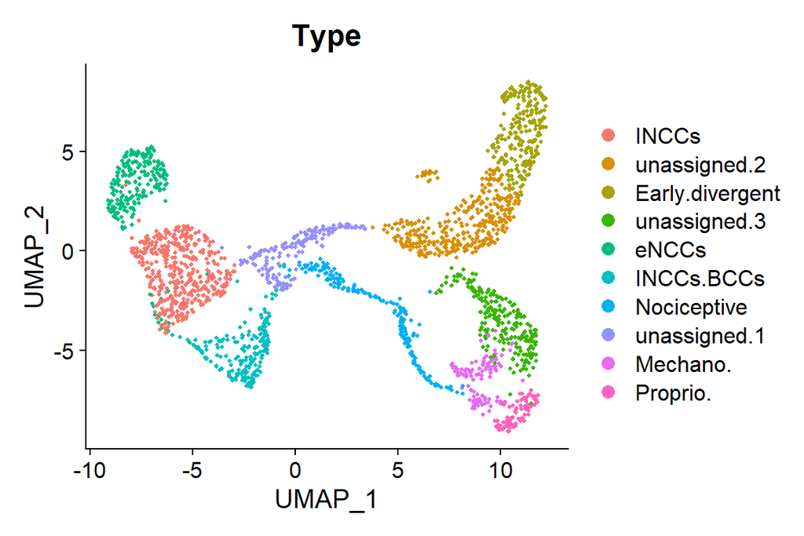

```r
# visualze the dataset
DimPlot(object = Data1, reduction = "umap", group.by = "Type", pt.size = 0.75)
```

```r
library(forcats)
# select the subset as input data
Data1.AB <- subset(x = Data1, subset = (Type == "INCCs" |
                                       Type == "INCCs.BCCs" |
                                       Type == "Nociceptive" |
                                       Type == "unassigned.1"|
                                       Type == "unassigned.2"))
Data1.AB@meta.data$Type <- fct_drop(Data1.AB@meta.data$Type)
```

# Part II: Load exFINDER database (and optional ligand-receptor database)

*exFINDER database* is available for human, mouse, and zebrafish. *ligand-receptor database* is used for inferring functionally related signaling pathways from the exSigNet, here we use the ligand-receptor database from CellChat.

```r
# load exFINDER database
load("../data/LR_layer1_mouse.rda")
load("../data/RTF_layer2_mouse.rda")
load("../data/TFT_layer3_mouse.rda")

exFINDER.M <- list()
exFINDER.M[[1]] <- LR_layer1_mouse
exFINDER.M[[2]] <- RTF_layer2_mouse
exFINDER.M[[3]] <- TFT_layer3_mouse
```

```r
# load CellChatDB
# load("../data/interaction_input_CellChatDB_human.rda")
load("../data/interaction_input_CellChatDB_mouse.rda")
# load("../data/interaction_input_CellChatDB_zebrafish.rda")
```

## Prepare the inputs for exFINDER analysis

```r
exp.data <- Data1.AB@assays$RNA@data
meta.data <- Data1.AB@meta.data
```

# Part III: Critical transition analysis using BioTIP

Here, we followed the official workflow of BioTIP: https://bioconductor.org/packages/release/bioc/vignettes/BioTIP/inst/doc/BioTIP.html

```r
# load BioTIP and dependent packages
library(BioTIP)
library(cluster)
library(GenomicRanges)
library(Hmisc)
library(MASS)
require(stringr)
require(psych)
```

```r
require(igraph)
```

```r
meta <- data.frame(meta.data)
Data <- data.frame(Data1.AB@assays$RNA@counts)
Data <-log2(Data+1)

meta$cell_barcode <- rownames(meta)
colnames(Data) <- t(meta$cell_barcode)

meta$Type <- as.character(meta$Type)
meta$orig.ident <- as.character(meta$orig.ident)
```

```r
meta$group = meta$Type

samples <- split(meta[,"cell_barcode"],f = meta$group)
lapply(samples, length)
```

```
#> $INCCs
#> [1] 430
#>
#> $INCCs.BCCs
#> [1] 203
#>
#> $Nociceptive
#> [1] 189
#>
#> $unassigned.1
#> [1] 169
#>
#> $unassigned.2
#> [1] 366
```

```r
test <- sd_selection(Data, samples, cutoff = 0.05)

igraphL <- getNetwork(test, fdr = 0.05)
```

```
#> INCCs:1219 nodes
#> INCCs.BCCs:1223 nodes
#> Nociceptive:1224 nodes
#> unassigned.1:1224 nodes
#> unassigned.2:1224 nodes
```

```r
cluster <- getCluster_methods(igraphL)

names(cluster)
```

```
#> [1] "INCCs"        "INCCs.BCCs"   "Nociceptive"  "unassigned.1" "unassigned.2"
```

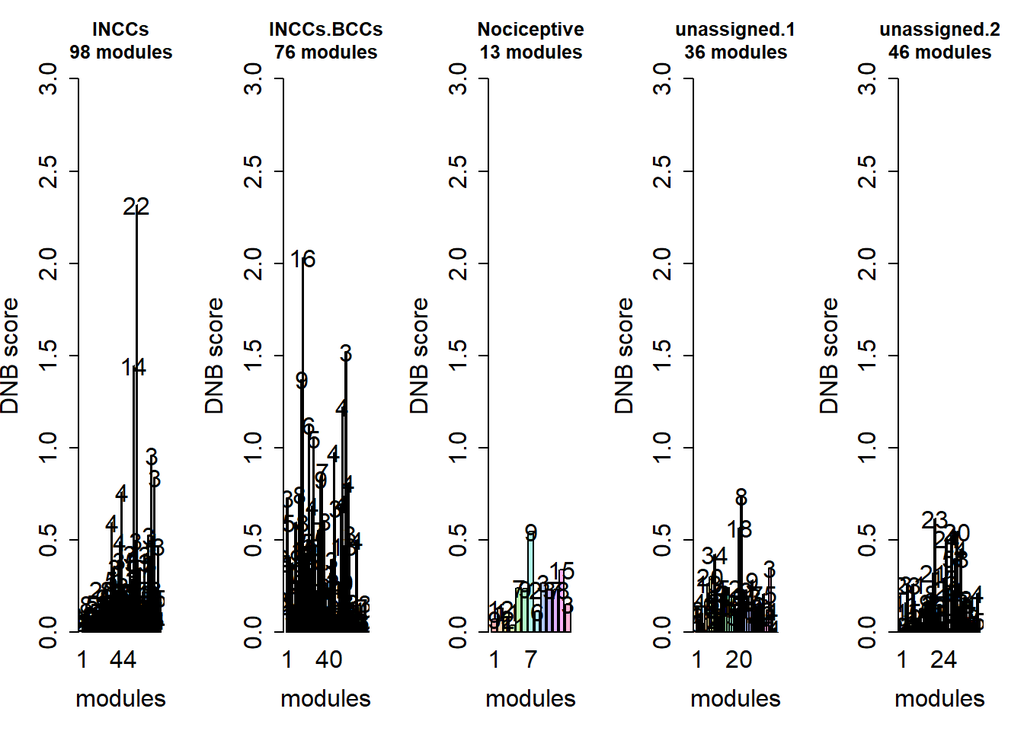

```r
membersL_noweight <- getMCI(cluster, test)
plotBar_MCI(membersL_noweight,ylim = c(0,3))
```

```r
maxMCIms <- getMaxMCImember(membersL_noweight[[1]],membersL_noweight[[2]], minsize = 10)
names(maxMCIms)
```

```
#> [1] "idx"     "members"
```

```r
names(maxMCIms[[1]])
```

```
#> [1] "INCCs"        "INCCs.BCCs"   "Nociceptive"  "unassigned.1" "unassigned.2"
```

```r
names(maxMCIms[[2]])
```

```
#> [1] "INCCs"        "INCCs.BCCs"   "Nociceptive"  "unassigned.1" "unassigned.2"
```

```r
head(maxMCIms[['idx']])
```

[output not shown]

```r
biomodules = getMaxStats(membersL_noweight[['members']],maxMCIms[[1]])
maxMCI = getMaxStats(membersL_noweight[['MCI']],maxMCIms[[1]])
maxMCI = maxMCI[order(maxMCI,decreasing=TRUE)]
head(maxMCI)
```

```
#>        INCCs   INCCs.BCCs unassigned.2 unassigned.1  Nociceptive
#>    2.3156366    2.0306131    0.6172523    0.5669360    0.3404172
```

```r
topMCI = getTopMCI(membersL_noweight[[1]],membersL_noweight[[2]],membersL_noweight[['MCI']],min = 10)
head(topMCI)
```

```
#>    INCCs
#> 2.315637
```

```r
maxSD = getMaxStats(membersL_noweight[['sd']],maxMCIms[[1]])
head(maxSD)
```

```
#>        INCCs   INCCs.BCCs  Nociceptive unassigned.1 unassigned.2
#>  0.043891185  0.047710745  0.007528862  0.028157284  0.039092630
```

```r
CTS = getCTS(topMCI, maxMCIms[[2]])
```

```
#> Length: 22
```

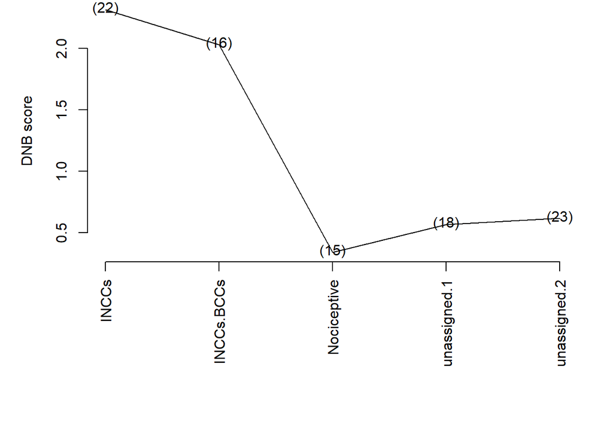

```r
par(mar = c(10,5,0,2))
plotMaxMCI(maxMCIms,membersL_noweight[[2]],states = names(samples),las = 2)
```